# Analysis of Biological networks

```r
library(igraph)
library(visNetwork)
library(rcartocolor)
library(readr)
library(ggplot2)
```

```r
# 1. Create a simple biological network using igraph

# Define the nodes (genes, proteins, etc.)
nodes <- data.frame(id = 1:6,
                    label = c("Gene1", "Gene2", "Gene3", "Gene4", "Gene5", "Gene6"),
                    group = c("A", "A", "B", "B", "C", "C"))
```

```r
# Define the edges (interactions between genes/proteins)
edges <- data.frame(from = c(1, 1, 2, 3, 4, 5, 5),
                    to = c(2, 3, 4, 5, 6, 6, 1))
```

```r
# Create the graph object with igraph
g <- graph_from_data_frame(d = edges, vertices = nodes, directed = FALSE)

# Display basic information about the network
print(g)
```

```
## IGRAPH 74d2776 UN-- 6 7 --
## + attr: name (v/c), label (v/c), group (v/c)
## + edges from 74d2776 (vertex names):
## [1] 1--2 1--3 2--4 3--5 4--6 5--6 1--5
```

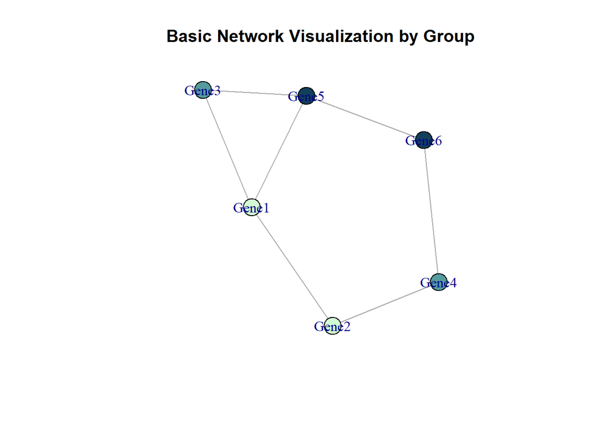

```r
# 2. Basic visualization with igraph

# Map groups to colors using rcartocolor palette "DarkMint"
group_colors <- rcartocolor::carto_pal(n = length(unique(nodes$group)), name = "DarkMint")
names(group_colors) <- unique(nodes$group)
V(g)$color <- group_colors[V(g)$group]

# Basic plot with igraph
plot(g, vertex.label = V(g)$label, vertex.color = V(g)$color, main = "Basic Network Visualization by Group")
```

```r
# 3. Interactive visualization with visNetwork

# Convert the igraph object to a format compatible with visNetwork
nodes_vis <- data.frame(id = V(g)$name,
                        label = V(g)$label,
                        group = V(g)$group,
                        color = group_colors[V(g)$group])

edges_vis <- data.frame(from = as.numeric(as.character(edges$from)),
                        to = as.numeric(as.character(edges$to)))
```

```r
# Create the interactive network
visNetwork(nodes_vis, edges_vis) %>%
  visOptions(highlightNearest = TRUE, nodesIdSelection = TRUE) %>%
  visGroups(groupname = "A", color = group_colors["A"]) %>%
  visGroups(groupname = "B", color = group_colors["B"]) %>%
  visGroups(groupname = "C", color = group_colors["C"])
```

[interactive chart not shown]

```r
# 4. Basic network analysis

# Calculate the degree of each node
degree_values <- degree(g)
print(degree_values)
```

```
## 1 2 3 4 5 6
## 3 2 2 2 3 2
```

```r
# Visualize the degree of each node using visNetwork
nodes_vis$size <- degree_values * 10  # Scale the size for visualization
visNetwork(nodes_vis, edges_vis) %>%
  visOptions(highlightNearest = TRUE, nodesIdSelection = TRUE) %>%
  visGroups(groupname = "A", color = group_colors["A"]) %>%
  visGroups(groupname = "B", color = group_colors["B"]) %>%
  visGroups(groupname = "C", color = group_colors["C"]) %>%
  visNodes(size = nodes_vis$size) %>%
  visLayout(randomSeed = 42) %>%
  visInteraction(zoomView = TRUE) %>%
  visPhysics(stabilization = FALSE)
```

[interactive chart not shown]

```r
# Calculate betweenness centrality
betweenness_values <- betweenness(g)
print(betweenness_values)
```

```
##   1   2   3   4   5   6
## 2.5 1.5 0.0 1.0 2.5 1.5
```

```r
# Visualize betweenness centrality using visNetwork
nodes_vis$size <- betweenness_values * 10  # Scale the size for visualization
visNetwork(nodes_vis, edges_vis) %>%
  visOptions(highlightNearest = TRUE, nodesIdSelection = TRUE) %>%
  visGroups(groupname = "A", color = group_colors["A"]) %>%
  visGroups(groupname = "B", color = group_colors["B"]) %>%
  visGroups(groupname = "C", color = group_colors["C"]) %>%
  visNodes(size = nodes_vis$size) %>%
  visLayout(randomSeed = 42) %>%
  visInteraction(zoomView = TRUE) %>%
  visPhysics(stabilization = FALSE)
```

[interactive chart not shown]

```r
# Calculate closeness centrality
closeness_values <- closeness(g)
print(closeness_values)
```

```
##         1         2         3         4         5         6
## 0.1428571 0.1250000 0.1111111 0.1111111 0.1428571 0.1250000
```

```r
# Visualize closeness centrality using visNetwork
nodes_vis$size <- closeness_values * 100  # Scale the size for visualization
visNetwork(nodes_vis, edges_vis) %>%
  visOptions(highlightNearest = TRUE, nodesIdSelection = TRUE) %>%
  visGroups(groupname = "A", color = group_colors["A"]) %>%
  visGroups(groupname = "B", color = group_colors["B"]) %>%
  visGroups(groupname = "C", color = group_colors["C"]) %>%
  visNodes(size = nodes_vis$size) %>%
  visLayout(randomSeed = 42) %>%
  visInteraction(zoomView = TRUE) %>%
  visPhysics(stabilization = FALSE)
```

[interactive chart not shown]

```r
# Generate simulated data
set.seed(42)  # For reproducibility
data <- matrix(rnorm(100), nrow = 10)  # 10 observations, 10 variables

# Create correlation matrix
correlation_matrix <- cor(data)
print(correlation_matrix)
```

```
##             [,1]       [,2]          [,3]         [,4]         [,5]
##  [1,]  1.0000000 -0.3749289  4.400510e-01 -0.403715753 -0.379728657
##  [2,] -0.3749289  1.0000000 -1.533438e-01  0.464777422 -0.210982663
##  [3,]  0.4400510 -0.1533438  1.000000e+00 -0.060023711 -0.691565680
##  [4,] -0.4037158  0.4647774 -6.002371e-02  1.000000000  0.003694893
##  [5,] -0.3797287 -0.2109827 -6.915657e-01  0.003694893  1.000000000
##  [6,] -0.3592186  0.2083099 -9.528598e-05  0.583813223  0.227040400
##  [7,] -0.1284330 -0.3527583 -2.145969e-01 -0.612631179  0.417634175
##  [8,] -0.2494999 -0.2494087 -3.952266e-01 -0.035617861  0.274254798
##  [9,]  0.2601430  0.2505148 -3.654942e-01 -0.210477536  0.403046802
## [10,]  0.2442616  0.2399034  2.332811e-01  0.250406749  0.033221095
##                [,6]        [,7]        [,8]       [,9]       [,10]
##  [1,] -3.592186e-01 -0.12843299 -0.24949987  0.2601430  0.24426162
##  [2,]  2.083099e-01 -0.35275830 -0.24940865  0.2505148  0.23990336
##  [3,] -9.528598e-05 -0.21459686 -0.39522662 -0.3654942  0.23328108
##  [4,]  5.838132e-01 -0.61263118 -0.03561786 -0.2104775  0.25040675
##  [5,]  2.270404e-01  0.41763418  0.27425480  0.4030468  0.03322109
##  [6,]  1.000000e+00 -0.06336527  0.37566159 -0.2856337  0.12588753
##  [7,] -6.336527e-02  1.00000000  0.17664898  0.1846653  0.07963793
##  [8,]  3.756616e-01  0.17664898  1.00000000 -0.3538231 -0.64126476
##  [9,] -2.856337e-01  0.18466526 -0.35382313  1.0000000  0.55090017
## [10,]  1.258875e-01  0.07963793 -0.64126476  0.5509002  1.00000000
```

```r
# Define a threshold
threshold <- 0.5  # Only include correlations greater than |0.5|

# Create adjacency matrix
adjacency_matrix <- ifelse(abs(correlation_matrix) > threshold, 1, 0)
diag(adjacency_matrix) <- 0  # Ensure no self-loops
print(adjacency_matrix)
```

```
##       [,1] [,2] [,3] [,4] [,5] [,6] [,7] [,8] [,9] [,10]
##  [1,]    0    0    0    0    0    0    0    0    0     0
##  [2,]    0    0    0    0    0    0    0    0    0     0
##  [3,]    0    0    0    0    1    0    0    0    0     0
##  [4,]    0    0    0    0    0    1    1    0    0     0
##  [5,]    0    0    1    0    0    0    0    0    0     0
##  [6,]    0    0    0    1    0    0    0    0    0     0
##  [7,]    0    0    0    1    0    0    0    0    0     0
##  [8,]    0    0    0    0    0    0    0    0    0     1
##  [9,]    0    0    0    0    0    0    0    0    0     1
## [10,]    0    0    0    0    0    0    0    1    1     0
```

```r
# Load igraph for graph manipulation
library(igraph)

# Convert adjacency matrix to edge list
edge_list <- as.data.frame(as_edgelist(graph_from_adjacency_matrix(adjacency_matrix)))
colnames(edge_list) <- c("from", "to")
print(edge_list)
```

```
##    from to
## 1     3  5
## 2     4  6
## 3     4  7
## 4     5  3
## 5     6  4
## 6     7  4
## 7     8 10
## 8     9 10
## 9    10  8
## 10   10  9
```

```r
# Create a data frame of nodes
nodes <- data.frame(id = 1:ncol(adjacency_matrix),
                    label = paste("Var", 1:ncol(adjacency_matrix), sep = ""),
                    group = sample(1:2, ncol(adjacency_matrix), replace = TRUE))  # Optional grouping
print(nodes)
```

```
##    id label group
## 1   1  Var1     2
## 2   2  Var2     2
## 3   3  Var3     1
## 4   4  Var4     2
## 5   5  Var5     1
## 6   6  Var6     1
## 7   7  Var7     2
## 8   8  Var8     2
## 9   9  Var9     2
## 10 10 Var10     2
```

```r
# Load visNetwork package
library(visNetwork)

# Visualize the network
visNetwork(nodes, edge_list) %>%
  visOptions(highlightNearest = TRUE, nodesIdSelection = TRUE) %>%
  visLayout(randomSeed = 22)  # For reproducibility
```

[interactive chart not shown]

1. **Degree**:
   - **What it is**: The degree of a node is the number of connections (or edges) it has with other nodes.
   - **Why it’s used**: In a protein-protein interaction (PPI) network, the degree can indicate how many interactions a protein has with other proteins. Proteins with a high degree may be crucial for the stability and functionality of the network because they interact with many other proteins.
   - **What information it provides**: Identifying proteins with a high degree can help you discover key proteins or “hubs” that may play important roles in biological processes or diseases.
2. **Betweenness Centrality**:
   - **What it is**: Betweenness centrality measures the number of times a node acts as a bridge along the shortest path between two other nodes.
   - **Why it’s used**: In PPI networks, betweenness centrality can indicate proteins that control the flow of information or interaction between different parts of the network. These proteins can be critical for communication within the network.
   - **What information it provides**: Proteins with high betweenness centrality might be potential targets for drug development because they control key interaction pathways in the network.
3. **Closeness Centrality**:
   - **What it is**: Closeness centrality measures how close a node is to all other nodes in the network, based on the shortest paths.
   - **Why it’s used**: In PPI networks, closeness centrality can indicate how quickly a protein can interact with other proteins. Proteins with high closeness centrality can quickly disseminate signals or interact with many parts of the network.
   - **What information it provides**: Identifying proteins with high closeness centrality can help you find proteins that are efficient at spreading information or signals across the network.

### Community Detection

- **What it is**: Community detection involves identifying groups of nodes (or proteins) that are more densely connected to each other than to the rest of the network.
- **Why it’s used**: In PPI networks, communities can represent functional modules, where proteins within the same community are involved in the same biological process or pathway.
- **What information it provides**: Detecting communities can help you understand the modular structure of the network and identify sets of proteins that work together, which is valuable for understanding complex biological functions and disease mechanisms.
1. Load Libraries: `igraph`: For network analysis and graph operations. `visNetwork`: For creating interactive network visualizations. `rcartocolor`: For using color palettes. `readr`: For reading data from files. `ggplot2`: For creating plots.

```r
library(igraph)
library(visNetwork)
library(rcartocolor)
library(readr)
library(ggplot2)
```

2.Set Seed: `set.seed(22)`: Ensures reproducibility by setting the random seed to 22.

```r
# Set the seed for reproducibility
set.seed(22)
```

3. Load Data and Create Graph: `readr::read_tsv("alzheimer_edges_stringdb.tsv")`: Reads the edge data from a TSV file into a data frame. `graph.data.frame(d = df_edges, directed = FALSE)`: Creates an undirected graph from the data frame.

```r
# Load data from the TSV file
df_edges <- readr::read_tsv("alzheimer_edges_stringdb.tsv")
g <- graph.data.frame(d = df_edges, directed = FALSE)
```

4. Prepare Nodes for Visualization: `data.frame(id = V(g)$name, label = V(g)$name, size = 10)`: Creates a nodes data frame with columns id, label, and size from the graph’s vertices.

```r
# Convert igraph object to visNetwork format:
nodes <- data.frame(id = V(g)$name, label = V(g)$name, size = 10)
```

5. `rcartocolor::carto_pal(n = length(V(g)), name = "DarkMint")`: Generates a color palette with the same number of colors as there are nodes in the graph. `nodes$color <- palette:` Assigns the generated colors to the nodes.

```r
# Generate colors based on the 'DarkMint' palette from rcartocolor
palette <- rcartocolor::carto_pal(n = length(V(g)), name = "DarkMint")
nodes$color <- palette
```

6. `as.data.frame(get.edgelist(g))`: Converts the edge list of the graph to a data frame. `colnames(edges) <- c("from", "to")`: Renames the columns to from and to for compatibility with visNetwork.

```r
edges <- as.data.frame(get.edgelist(g))
colnames(edges) <- c("from", "to")
```

```r
# Create and display the interactive network with stabilized layout
network <- visNetwork(nodes, edges, width = "100%", height = "800px") %>%
  visEdges(smooth = TRUE) %>%
  visOptions(highlightNearest = TRUE, nodesIdSelection = TRUE) %>%
  visPhysics(stabilization = list(enabled = TRUE, iterations = 10, updateInterval = 10),
             solver = "barnesHut") %>%
  visInteraction(dragNodes = TRUE, dragView = TRUE, zoomView = TRUE)

network  # Display the network in the viewer
```

[interactive chart not shown]

```r
# Save the network visualization as an HTML file
network %>% visSave("ppinetwork.html")
```

8. Calculate Node Degree: `degree(g)`: Calculates the degree (number of connections) for each node in the graph.

```r
# Calculate node degree
degree_values <- degree(g)
```

9. `data.frame(degree = degree_values)`: Creates a data frame for the degree values. `ggplot(degree_distribution, aes(x = degree)) + geom_histogram(binwidth = 1, fill = 'darkblue', color = 'black') + labs(title = "Degree Distribution", x = "Degree", y = "Frequency")`: Plots the degree distribution using ggplot2 with a histogram, and customizes the plot with titles and labels. `ggsave("degree_distribution.png", plot = degree_plot, width = 10, height = 7, dpi = 300)`: Saves the degree distribution plot as a PNG file with specified dimensions and resolution.

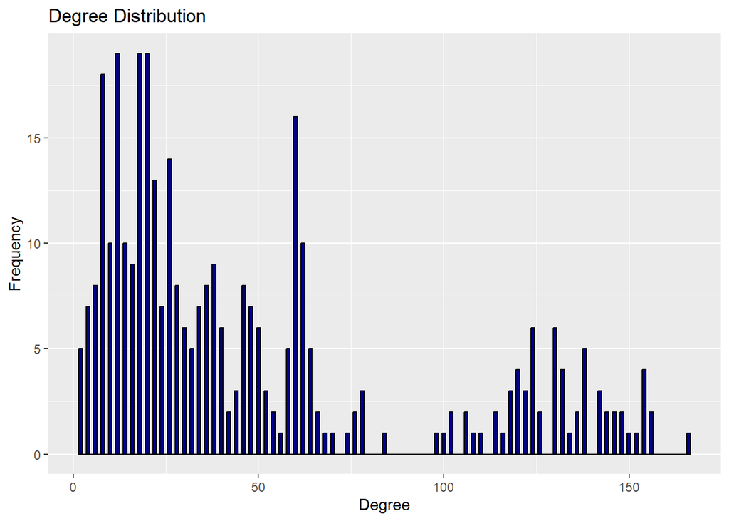

```r
# Plot degree distribution
degree_distribution <- data.frame(degree = degree_values)
degree_plot <- ggplot(degree_distribution, aes(x = degree)) +
  geom_histogram(binwidth = 1, fill = 'darkblue', color = 'black') +
  labs(title = "Degree Distribution", x = "Degree", y = "Frequency")
degree_plot
```

```r
# Save degree distribution plot
ggsave("degree_distribution.png", plot = degree_plot, width = 10, height = 7, dpi = 300)
```

10. Normalize Node Sizes Based on Degree: Define the minimum (`min_size = 10`) and maximum (`max_size = 50`) node sizes. Normalize the node sizes based on their degree values. Update the nodes data frame (`nodes_degree`) with the normalized sizes.

```r
# Normalize node sizes based on degree
min_size <- 10
max_size <- 50
normalized_degree_sizes <- min_size + (degree_values - min(degree_values)) / (max(degree_values) - min(degree_values)) * (max_size - min_size)
nodes_degree <- nodes
nodes_degree$size <- normalized_degree_sizes
```

11. Visualize Network with Node Sizes Based on Degree: visNetwork(nodes_degree, edges): Initializes the network visualization with nodes sized by normalized degree values. visEdges(smooth = FALSE): Disables smooth edges. visOptions(highlightNearest = TRUE, nodesIdSelection = TRUE): Enables options for highlighting the nearest nodes and selecting nodes by ID. visPhysics(solver = “barnesHut”, stabilization = list(enabled = TRUE, iterations = 1000)): Applies physics settings using the Barnes-Hut solver for layout stabilization. visInteraction(dragNodes = TRUE, dragView = TRUE, zoomView = TRUE): Enables interaction options like dragging nodes and zooming. visEvents(stabilizationIterationsDone = “function () {this.setOptions({physics: false});}”): Disables physics after stabilization iterations are done.

```r
# Create and display the interactive network with nodes sized by normalized degree
node_degree_network <- visNetwork(nodes_degree, edges, width = "100%", height = "800px") %>%
  visEdges(smooth = FALSE) %>%
  visOptions(highlightNearest = TRUE, nodesIdSelection = TRUE) %>%
  visPhysics(solver = "barnesHut", stabilization = list(enabled = TRUE, iterations = 1000)) %>%
  visInteraction(dragNodes = TRUE, dragView = TRUE, zoomView = TRUE) %>%
  visEvents(stabilizationIterationsDone = "function () {this.setOptions({physics: false});}")

# Display the updated network in the viewer
node_degree_network
```

[interactive chart not shown]

```r
# Save the updated network visualization as an HTML file
node_degree_network %>% visSave("network_degree.html")
```

12. Print Top 10 Nodes by Degree: `head(sort(degree_values, decreasing = TRUE), 10)`: Gets the top 10 nodes with the highest degree. `cat("Top 10 nodes by degree:\n")`: Prints a header. `print(top_degree_nodes)`: Prints the top 10 nodes by degree.

```r
# Print top 10 nodes by degree
top_degree_nodes <- head(sort(degree_values, decreasing = TRUE), 10)
cat("Top 10 nodes by degree:\n")
```

```
## Top 10 nodes by degree:
```

```r
print(top_degree_nodes)
```

```
## UQCRFS1   COX5A   COX5B  COX4I1   UQCRB  UQCRC2   UQCRQ    CYC1  UQCR10  NDUFB8
##     166     156     156     154     154     154     154     152     150     148
```

13. Calculate Betweenness Centrality: betweenness(g): Calculates the betweenness centrality for each node in the graph.

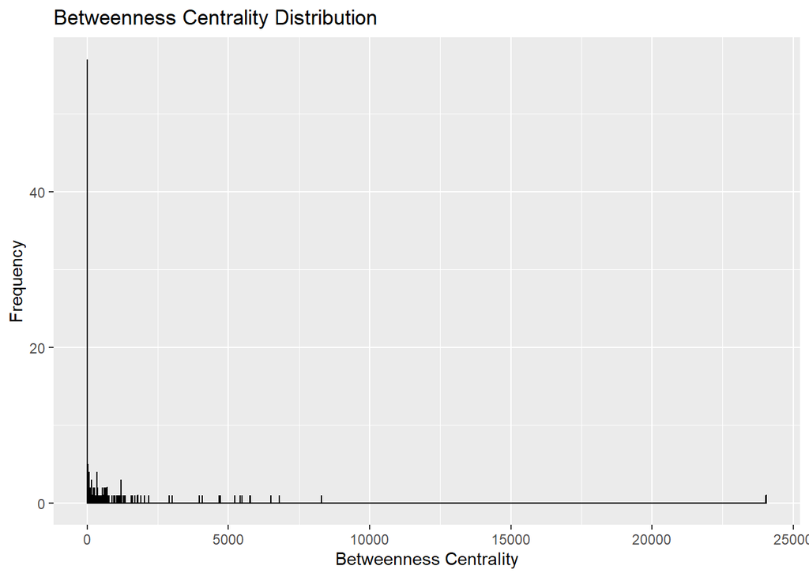

```r
# Calculate betweenness centrality
betweenness_values <- betweenness(g)

# Plot betweenness centrality distribution
betweenness_distribution <- data.frame(betweenness = betweenness_values)
betweenness_plot <- ggplot(betweenness_distribution, aes(x = betweenness)) +
  geom_histogram(binwidth = 1, fill = 'darkblue', color = 'black') +
  labs(title = "Betweenness Centrality Distribution", x = "Betweenness Centrality", y = "Frequency")
betweenness_plot
```

```r
# Save betweenness centrality distribution plot
ggsave("betweenness_distribution.png", plot = betweenness_plot, width = 10, height = 7, dpi = 300)

# Normalize node sizes based on betweenness centrality
normalized_betweenness_sizes <- min_size + (betweenness_values - min(betweenness_values)) / (max(betweenness_values) - min(betweenness_values)) * (max_size - min_size)
nodes_betweenness <- nodes
nodes_betweenness$size <- normalized_betweenness_sizes

# Create and display the interactive network with nodes sized by normalized betweenness centrality
betweenness_centrality_network <- visNetwork(nodes_betweenness, edges, width = "100%", height = "800px") %>%
  visEdges(smooth = FALSE) %>%
  visOptions(highlightNearest = TRUE, nodesIdSelection = TRUE) %>%
  visPhysics(solver = "barnesHut", stabilization = list(enabled = TRUE, iterations = 1000)) %>%
  visInteraction(dragNodes = TRUE, dragView = TRUE, zoomView = TRUE) %>%
  visEvents(stabilizationIterationsDone = "function () {this.setOptions({physics: false});}")

# Display the updated network in the viewer
betweenness_centrality_network
```

[interactive chart not shown]

```r
# Save the updated network visualization as an HTML file
betweenness_centrality_network %>% visSave("network_betweenness.html")
```

14. Print Top 10 Nodes by Betweenness Centrality

```r
top_betweenness_nodes <- head(sort(betweenness_values, decreasing = TRUE), 10)
cat("Top 10 nodes by betweenness centrality:\n")
```

```
## Top 10 nodes by betweenness centrality:
```

```r
print(top_betweenness_nodes)
```

```
##      CYCS     CASP3    CTNNB1      SNCA      MAPT     GSK3B     VDAC1      MTOR
## 24037.916  8296.695  6808.497  6500.766  5785.474  5754.728  5483.320  5422.067
##     PSMC3     ITPR3
##  5229.973  4711.869
```

15. Calculate Closeness Centrality:

```r
# Calculate closeness centrality
closeness_values <- closeness(g)


# Normalize node sizes based on closeness centrality
normalized_closeness_sizes <- min_size + (closeness_values - min(closeness_values)) / (max(closeness_values) - min(closeness_values)) * (max_size - min_size)
nodes_closeness <- nodes
nodes_closeness$size <- normalized_closeness_sizes

# Create and display the interactive network with nodes sized by normalized closeness centrality
closeness_centrality_network <- visNetwork(nodes_closeness, edges, width = "100%", height = "800px") %>%
  visEdges(smooth = FALSE) %>%
  visOptions(highlightNearest = TRUE, nodesIdSelection = TRUE) %>%
  visPhysics(solver = "barnesHut", stabilization = list(enabled = TRUE, iterations = 1000)) %>%
  visInteraction(dragNodes = TRUE, dragView = TRUE, zoomView = TRUE) %>%
  visEvents(stabilizationIterationsDone = "function () {this.setOptions({physics: false});}")

# Display the updated network in the viewer
closeness_centrality_network
```

[interactive chart not shown]

```r
# Save the updated network visualization as an HTML file
closeness_centrality_network %>% visSave("network_closeness.html")
```

16. Print Top 10 Nodes by Closeness Centrality:

```r
top_closeness_nodes <- head(sort(closeness_values, decreasing = TRUE), 10)
cat("Top 10 nodes by closeness centrality:\n")
```

```
## Top 10 nodes by closeness centrality:
```

```r
print(top_closeness_nodes)
```

```
##        CASP3         CYCS         AKT1        ITPR3        ITPR1         MAPT
## 0.0010964912 0.0010672359 0.0010570825 0.0010471204 0.0010449321 0.0010152284
##          INS        VDAC1         AKT2         AKT3
## 0.0010030090 0.0010000000 0.0009960159 0.0009960159
```

```r
# Calculate eigenvector centrality
eigenvector_values <- eigen_centrality(g)$vector

# Normalize node sizes based on eigenvector centrality
normalized_eigenvector_sizes <- min_size + (eigenvector_values - min(eigenvector_values)) /
  (max(eigenvector_values) - min(eigenvector_values)) * (max_size - min_size)
nodes_eigenvector <- nodes
nodes_eigenvector$size <- normalized_eigenvector_sizes

# Create and display the interactive network with nodes sized by normalized eigenvector centrality
eigenvector_centrality_network <- visNetwork(nodes_eigenvector, edges, width = "100%", height = "800px") %>%
  visEdges(smooth = FALSE) %>%
  visOptions(highlightNearest = TRUE, nodesIdSelection = TRUE) %>%
  visPhysics(solver = "barnesHut", stabilization = list(enabled = TRUE, iterations = 1000)) %>%
  visInteraction(dragNodes = TRUE, dragView = TRUE, zoomView = TRUE) %>%
  visEvents(stabilizationIterationsDone = "function () {this.setOptions({physics: false});}")

# Display the updated network in the viewer
eigenvector_centrality_network
```

[interactive chart not shown]

```r
# Calculate clustering coefficient
clustering_values <- transitivity(g, type = "local", isolates = "zero")

# Normalize node sizes based on clustering coefficient
normalized_clustering_sizes <- min_size + (clustering_values - min(clustering_values)) /
  (max(clustering_values) - min(clustering_values)) * (max_size - min_size)
nodes_clustering <- nodes
nodes_clustering$size <- normalized_clustering_sizes

# Create and display the interactive network with nodes sized by normalized clustering coefficient
clustering_coefficient_network <- visNetwork(nodes_clustering, edges, width = "100%", height = "800px") %>%
  visEdges(smooth = FALSE) %>%
  visOptions(highlightNearest = TRUE, nodesIdSelection = TRUE) %>%
  visPhysics(solver = "barnesHut", stabilization = list(enabled = TRUE, iterations = 1000)) %>%
  visInteraction(dragNodes = TRUE, dragView = TRUE, zoomView = TRUE) %>%
  visEvents(stabilizationIterationsDone = "function () {this.setOptions({physics: false});}")

# Display the updated network in the viewer
clustering_coefficient_network
```

[interactive chart not shown]

17. Detect Communities Using the Louvain Method:

`cluster_louvain(g)`: Detects communities in the graph using the Louvain method. `membership(community)`: Extracts the community membership for each node. Assign Community Colors to Nodes:

Generate a color palette for the communities using `rcartocolor::carto_pal`. Assign colors to the nodes based on their community membership.

Visualize Network with Nodes Colored by Community Membership:

`visNetwork(nodes_communities, edges)`: Initializes the network visualization with nodes colored by community membership.

```r
# Detect communities using the Louvain method
community <- cluster_louvain(g)
membership <- membership(community)

# Assign community colors to nodes
num_communities <- length(unique(membership))
community_palette <- rcartocolor::carto_pal(n = num_communities, name = "DarkMint")
nodes_communities <- nodes
nodes_communities$color <- community_palette[membership]

# Create and display the interactive network with nodes colored by community membership
community_network <- visNetwork(nodes_communities, edges, width = "100%", height = "800px") %>%
  visEdges(smooth = FALSE) %>%
  visOptions(highlightNearest = TRUE, nodesIdSelection = TRUE) %>%
  visPhysics(solver = "barnesHut", stabilization = list(enabled = TRUE, iterations = 1000)) %>%
  visInteraction(dragNodes = TRUE, dragView = TRUE, zoomView = TRUE) %>%
  visEvents(stabilizationIterationsDone = "function () {this.setOptions({physics: false});}")

# Display the network with communities in the viewer
community_network
```

[interactive chart not shown]

```r
# Save the community network visualization as an HTML file
community_network %>% visSave("network_communities.html")
```